# PGD Data Training #2: Common Statistical Concepts and How to Interpret Them

Sarv Salvi

July 5th, 2018

### Introduction

Objective: Participants will be able to choose useful summary statistics to describe distributions of numeric variables.

Learning Goal 1: Be able to select between various summary statistics to communicate key information about a distribution.

Learning Goal 2: Be able to interpret and visualize the correlation coefficients to understand the relationship between two numeric variables.

Learning Goal 3: Develop a vocabulary that can be used to discuss distributions and correlations.

### Distributions

Definition: The distribution of a numeric variable is all the values that a variable takes in a data set and the number of occurrences of each value.

Example: The variable of percent repaid for each client has a distribution. It takes on range of values and the number of occurrences is the number of clients who have repaid a particular percentage.

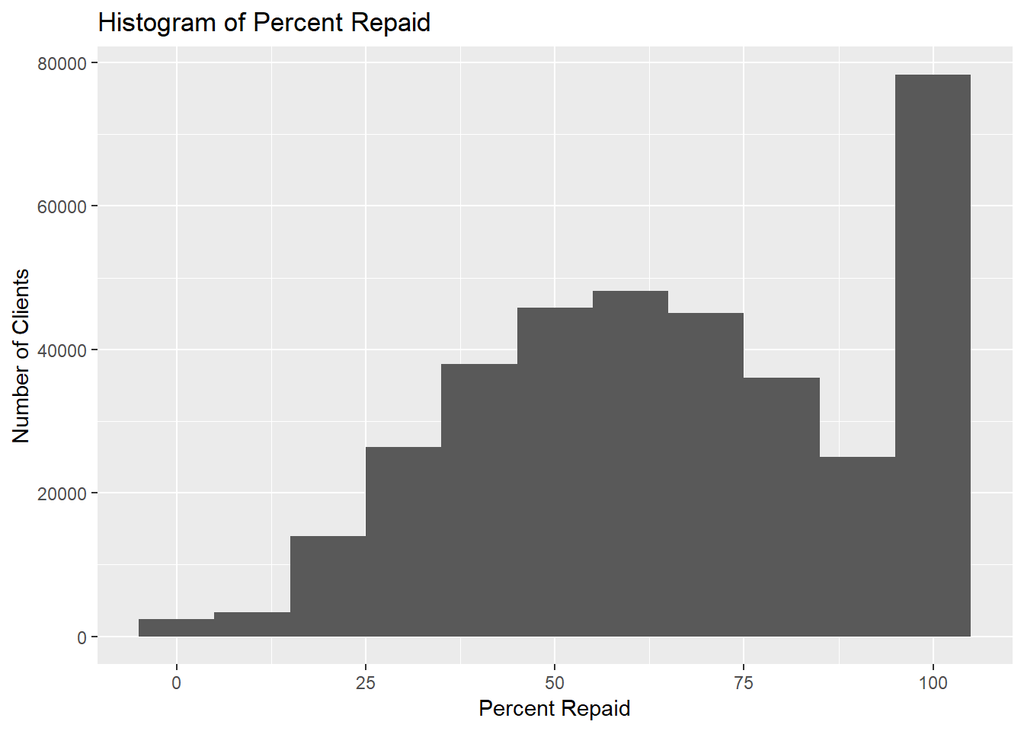

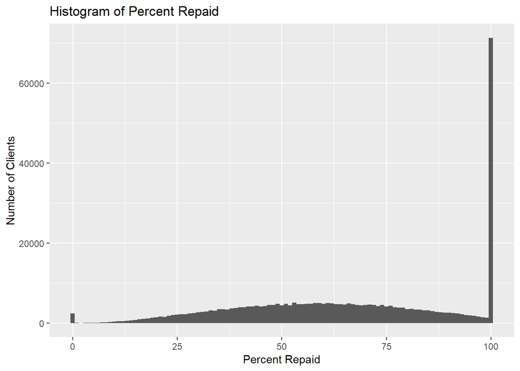

Summarizing the Distribution: When we are talking about a variable with others on our team, we often need to describe a distribution in a way that is useful for making decisions. Simply listing all values is not actionable information. The two most important things you can tell someone about a distribution are:

1. Central/typical value: A number that best represents the entire distribution by accounting for number of occurrences of each value. Mean, median, and mode are the most common statistics that are used to describe the “central/typical value”.
   - Mean: This is calculated by summing all of the values in the distributions and dividing the by the total number of values in the entire distribution. This is also called average.
   - Median: This is calculated by finding the observation that has half the observations less than it and half greater than it.
   - Mode: This is the value(s) that occur most frequently in the distribution.
2. Spread: This describes the arrangement of all values in relation to the “central/typical value”. Range and Inter-quartile range are common statistical concepts that have been created to describe “spread”.
   - Range: The range is the largest and smallest values in the distribution.
   - Inter-quartile Range (IQR): This is the range of observations that captures the middle 50% of observations. It is reported by giving the observation that is greater than 25% of all observations as the lower bound and the observation that is greater than 75% of all observations as the upper bound. It supplements range by giving a sense of how evenly individual values are spread throughout a distribution.

Discussion Questions: Split into small groups or pairs and discuss each of the questions below.

1. Choosing between Mean and Median: Below are some histograms which are a pretty common visual representation of a distribution. In a histogram we have “bins” that are used to represent the number of occurrences of the variable between the upper and lower bound of the bin. The bins are the width of the columns along the x-axis. The number of occurrences is the height of the bin along the y-axis. For each case discuss whether mean or median is the most appropriate description of the central/typical value and why. In each case the mean is the green line, the median is the red line.

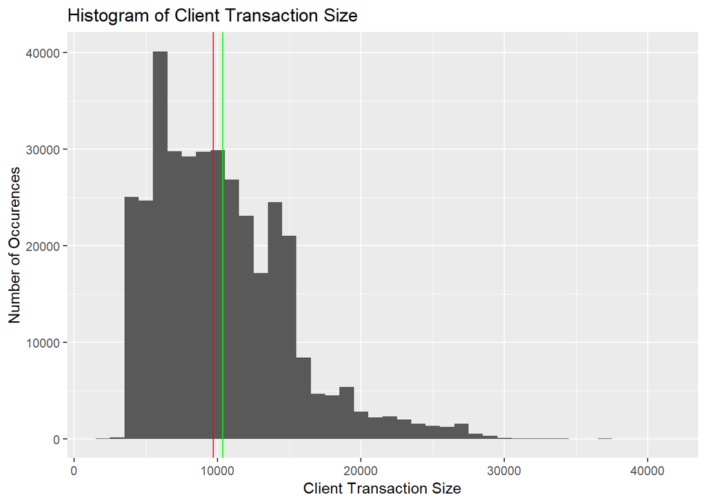

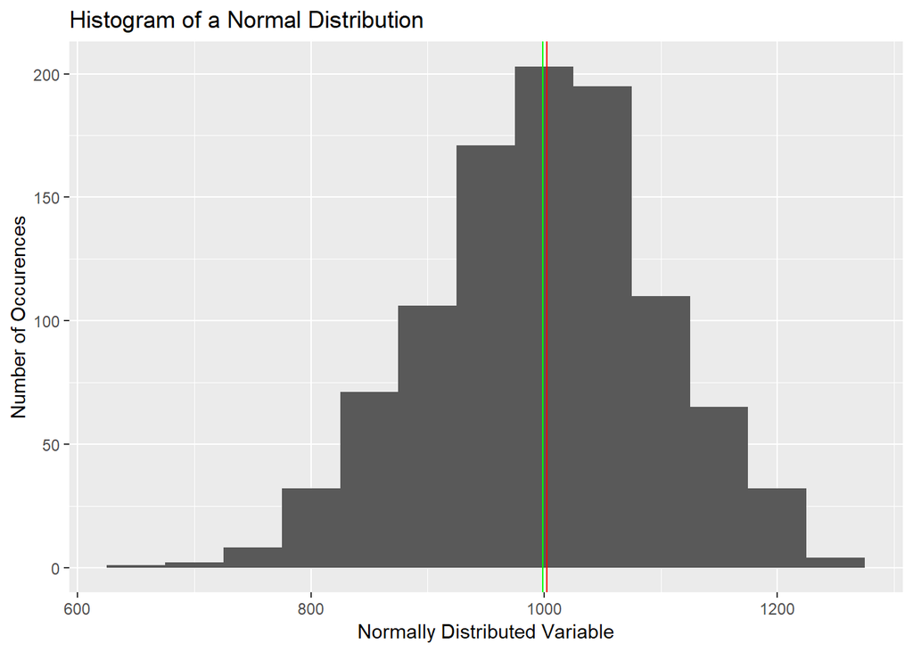

2. Follow-up on Mode: Look at the distributions above again and locate the approximate location of the mode. Discuss in small groups what information, if any, this gives us that is not contained in the median or mean.
3. Range and IQR: A box plot (a.k.a box and whisker plot) is a very common way of visually showing the range and the IQR. The range is shown by the entire vertical distance including the dots which just indicate an extreme value. The bottom line of the box is the 25th percentile, the line inside the box is the 50th (i.e. the median) and the top line of the box is the 75th percentile. IQR is represented by the box. Discuss how range and IQR provide different but useful pieces of information about the spread of the following distributions.

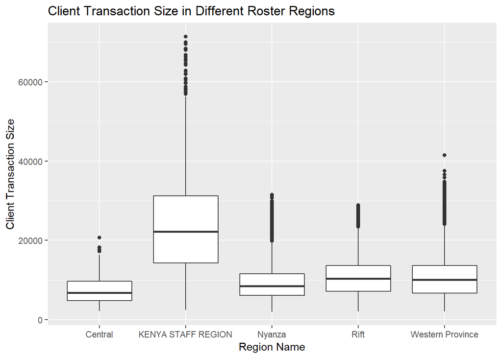

### Correlations

Definition: In the previous section, we looked at how to describe a single variable. Often we are interested in the relationship between two numeric variables. Correlation is a measure of how two numeric variables move in relation to each other. There are a few different ways correlation are commonly quantified by statisticians. The most common type of the correlation is the Pearson correlation coefficient. When people refer to correlation they most likely referring to the Pearson coefficient.

Interpreting Correlation: The Pearson correlation coefficient will always take a value between -1 and 1. Both 1 and -1 indicate a perfect linear relationship between the two variables. A value of -1 means that as one variable increases the other decreases proportionally - they have an strong negative correlation. A value of 1 means that as one variable increases the other variable also increases proportionally - they have a strong positive correlation. A correlation coefficient of 0 means that the two variables do not have a linear relationship.

Discussion Questions: Split into small groups or pairs and discuss the question below.

1. Visualizing Correlation: A common way of visualizing a correlation is by plotting the two variables in a scatter plot. Inspect the two scatter plots below and decide the following:
- Does the correlation appear strong or weak?
- Does the correlation appear to be positive or negative?
- Come up with a guess for what the Pearson correlation coefficients might be. Person with the lowest mean absolute deviation from the actual values gets a prize from me.

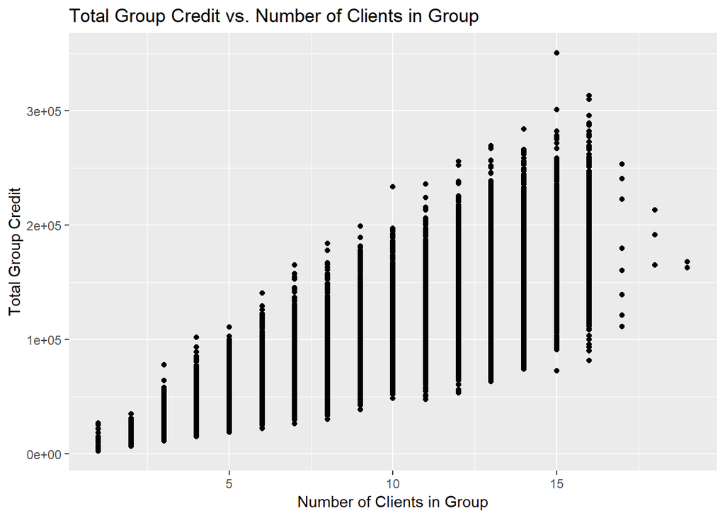

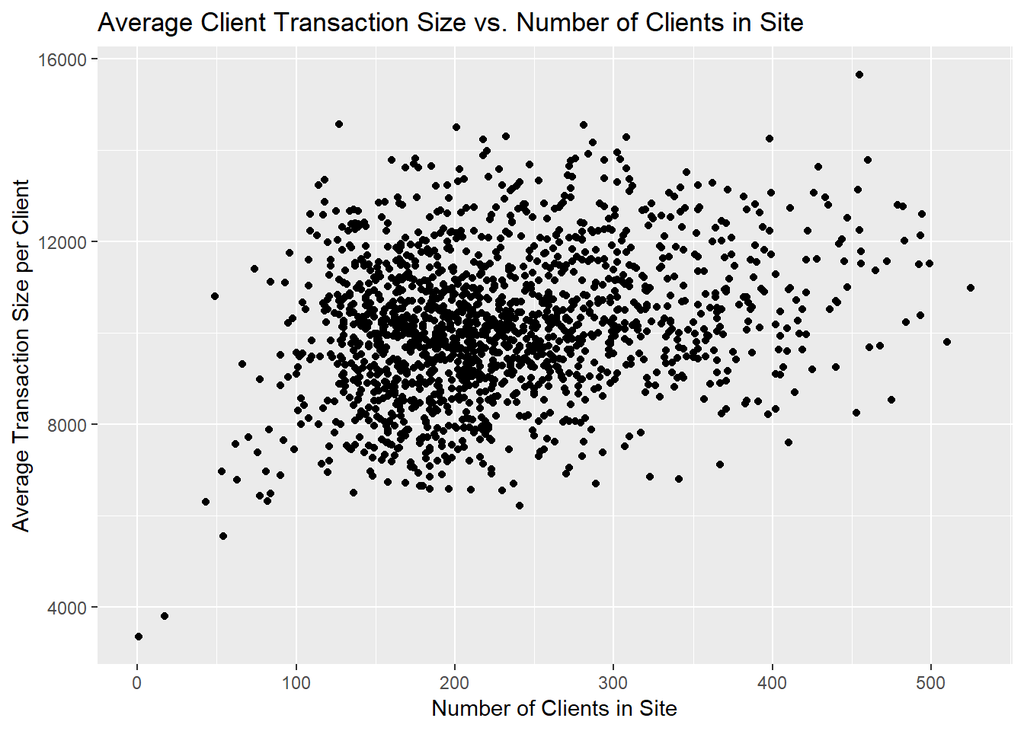